# Asylum Seekers Entering the EU

# 1. Exploratory Data Analysis

## 1.1. Data Source, Headers and Labels

**DATASET** “Asylum and first time asylum applicants by citizenship, age and sex Monthly data (rounded) [migr_asyappctzm]”  
**LAST UPDATE*** 19.03.19 06:51:45  
**EXTRACTION DATE** 19.03.19 13:19:35  
**SOURCE OF DATA** Eurostat

| Attribute | Values |
| --- | --- |
| TIME | “2008M01” to “2018M12” |
| GEO | “European Union - 28 countries” |
| CITIZEN | “Extra-EU28” |
| SEX | “Total”, “Males”, “Females” |
| AGE | “Total” |
| ASYL_APP | “Asylum applicant”, “First time applicant” |
| UNIT“ | “Person” |

No footnotes available.

Available flags:

- b,“break in time series”
- c,“confidential”
- d,“definition differs, see metadata”
- e,“estimated”
- f,“forecast”
- n,“not significant”
- p,“provisional”
- r,“revised”
- s,“Eurostat estimate”
- u,“low reliability”
- z,“not applicable”
- Special value: “:”,“not available”

## 1.2 Reading the data

```r
#set working directory
#setwd("~/DIT/Time Series 2 Forecasting/Project/2-Trend and seasonality")

#Graphical Parameters: For colours, color specifications, check colors() or, even better, demo(colors)

library(readr)
library(forecast)
library(tseries)
library(mgcv)
datafile <- read_csv("migr_asylum_applicant_EU28/migr_asyappctzm_1_Data.csv")
head(datafile)
```

| TIME | DATE_PATTERN | GEO | CITIZEN | SEX | AGE | ASYL_APP | UNIT | Value | Flag and Footnotes |
| --- | --- | --- | --- | --- | --- | --- | --- | --- | --- |
| 2008M01 | 01/01/08 | European Union - 28 countries | Extra-EU28 | Total | Total | Asylum applicant | Person | 18355 | NA |
| 2008M02 | 01/02/08 | European Union - 28 countries | Extra-EU28 | Total | Total | Asylum applicant | Person | 16885 | NA |
| 2008M03 | 01/03/08 | European Union - 28 countries | Extra-EU28 | Total | Total | Asylum applicant | Person | 15570 | NA |
| 2008M04 | 01/04/08 | European Union - 28 countries | Extra-EU28 | Total | Total | Asylum applicant | Person | 16975 | NA |
| 2008M05 | 01/05/08 | European Union - 28 countries | Extra-EU28 | Total | Total | Asylum applicant | Person | 17110 | NA |
| 2008M06 | 01/06/08 | European Union - 28 countries | Extra-EU28 | Total | Total | Asylum applicant | Person | 17520 | NA |

All column names:

```r
names(datafile)
```

```
##  [1] "TIME"               "DATE_PATTERN"       "GEO"
##  [4] "CITIZEN"            "SEX"                "AGE"
##  [7] "ASYL_APP"           "UNIT"               "Value"
## [10] "Flag and Footnotes"
```

Convert the values into a time series Plot Values against Time

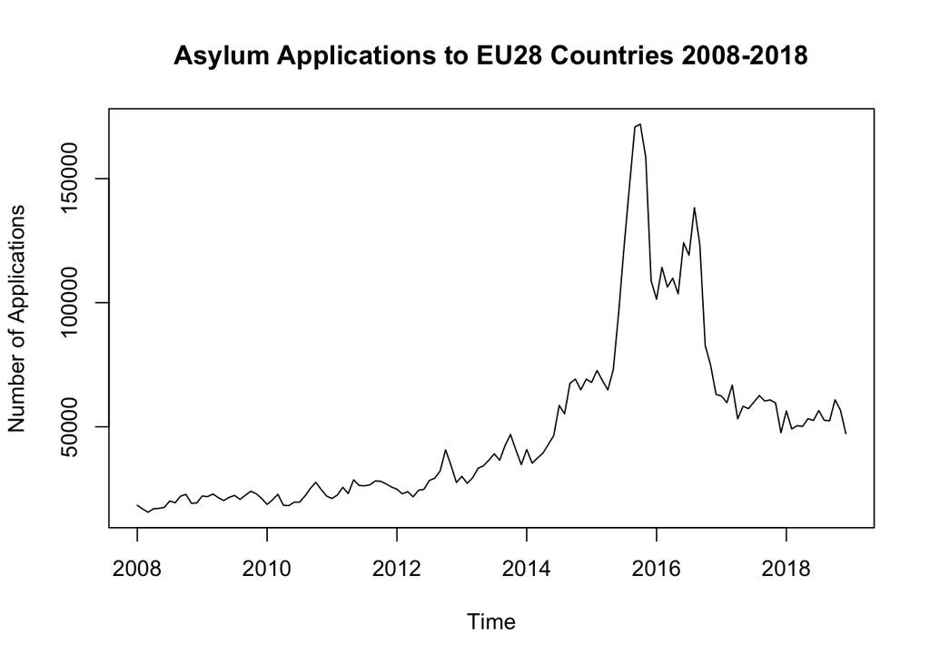

```r
values = datafile[9]
values = ts(values, start=2008, frequency=12)
ts.plot(values, main="Asylum Applications to EU28 Countries 2008-2018", ylab="Number of Applications")
```

***

# 2. Smoothing the data

We can use smoothing to reduce the volatility in our observed data and making it into a more stable and predictable series.

## Trend Analysis - non-parametric

```r
#Create equally spaced time points for fitting trends
time.pts = c(1:length(values))
time.pts = c(time.pts - min(time.pts))/max(time.pts)
```

### Fitting a moving average, kernel smoothing, loess and splines smoothing

```r
#define mav/smoothing methods, and fit
values.mafilter.fit = filter(values, filter = rep(1/4, 4), sides = 2)


ma.fit = ma(values, order=2)
values.fit.ma = ts(ma.fit, start=2008, frequency=12)

ksmooth.fit = ksmooth(time.pts, values, kernel = "box", bandwidth = 0.2)
values.fit.ksmooth = ts(ksmooth.fit$y,start=2008,frequency=12)

loess.fit = loess(as.matrix(values)~time.pts, data=values, span=0.2)
values.fit.loess = ts(predict(loess.fit), start=2008, frequency=12)

gam.fit = gam(values~s(time.pts))
values.fit.gam = ts(fitted(gam.fit),start=2008,frequency=12)
```

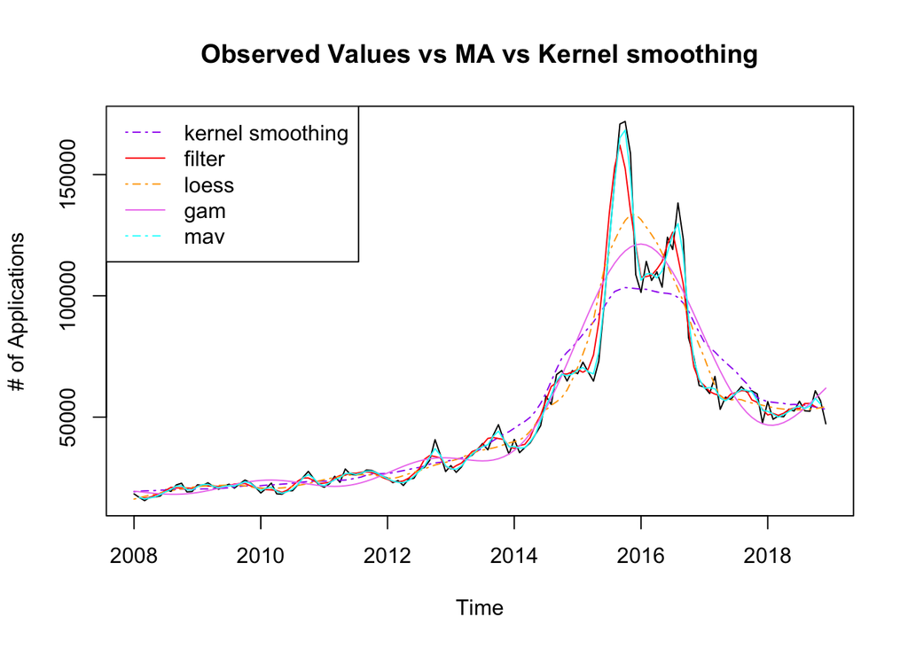

```r
# plot fits against values
ts.plot(values,ylab="# of Applications", main="Observed Values vs MA vs Kernel smoothing")
lines(values.fit.ksmooth,lwd=1, lty=4 ,col="purple")
lines(values.mafilter.fit, col="red")
lines(values.fit.loess, col="orange", lty=4)
lines(values.fit.gam, col="violet")
lines(values.fit.ma, col="cyan")
legend(x="topleft",c("kernel smoothing", "filter", "loess", "gam", "mav"),lty = c(4, 1), col=c("purple","red", "orange", "violet", "cyan"))
```

```r
#values.fit.mav is the ma dataframe (type of the objects is float) with the transformed values for each entry
#ablines is an a, b line graphing function, a is y intercept and b is slope
```

It’s a matter of balancing smoothness to make predictability easier and accuracy. Pick filter(red) or moving average(cyan).

# 3. Decomposing the data

Trend component, seasonal component and residuals (random/white noise). We assume this series is additive (instead of multiplicative).

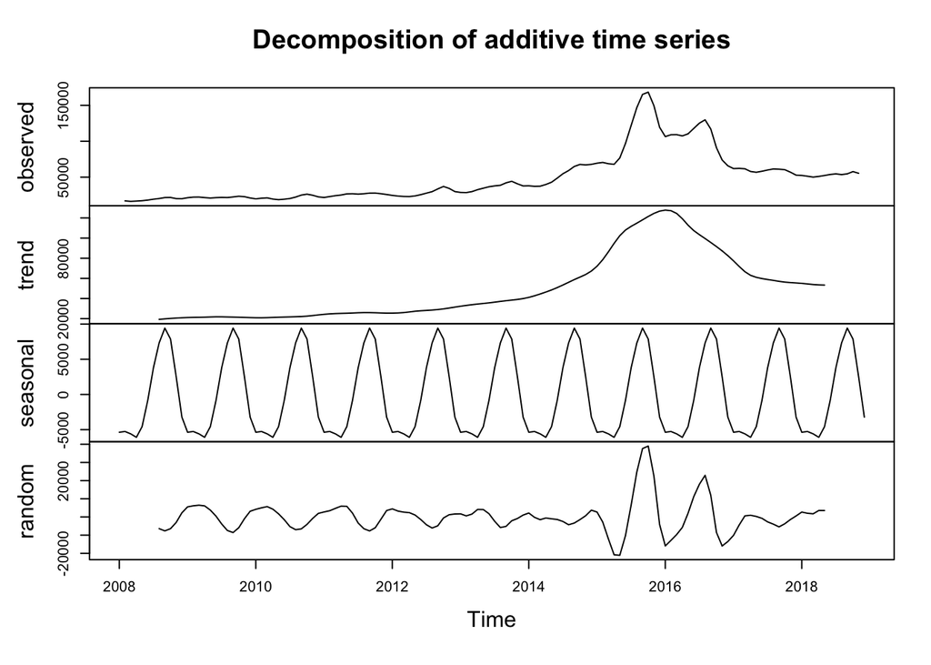

```r
values.ma.decomp = decompose(values.fit.ma, type=c("additive"))
plot(values.ma.decomp)
```

A more detailed decomposition of this time-series can be seen below by using STL - Seasonal Decomposition of Time Series by LOESS:

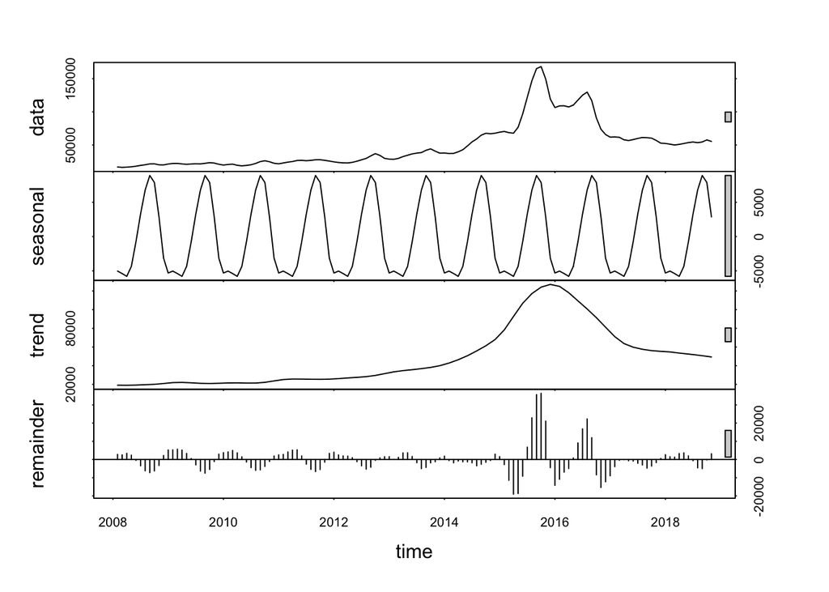

```r
values.decomp.stl <- stl(na.omit(values.fit.ma[, 1]), s.window="periodic")
plot(values.decomp.stl)
```

Using the decomposed time series, we can subtract the $seasonal component from the data and de-seasonalize it - which can be useful to apply an ARIMA process, instead of SARIMA.

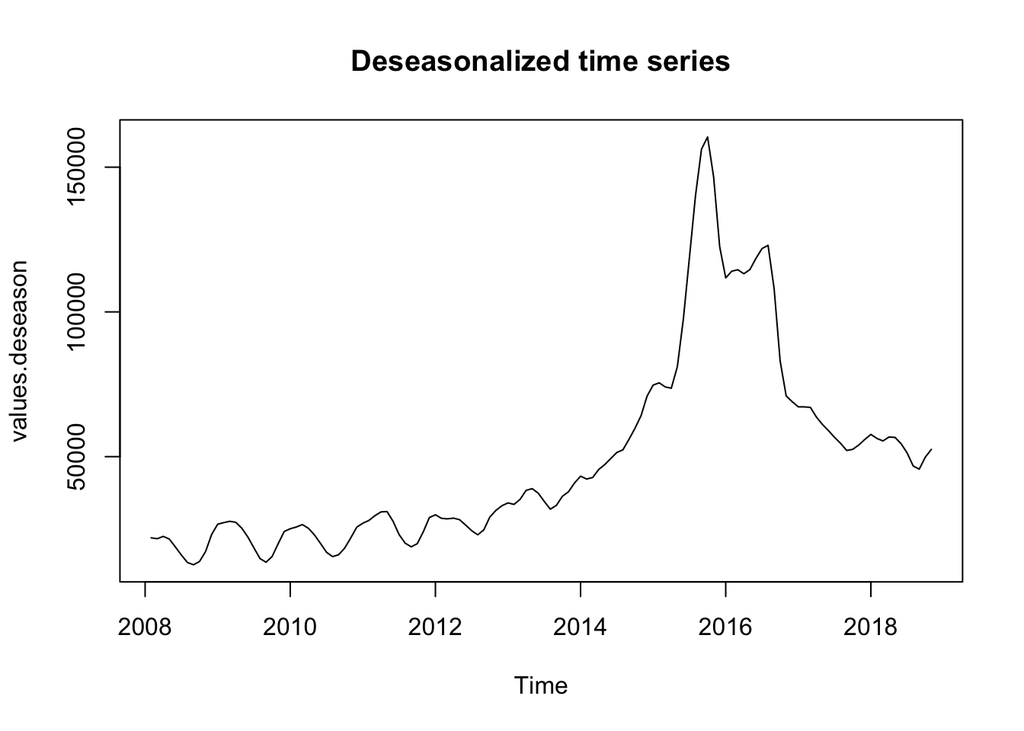

```r
values.deseason = seasadj(values.decomp.stl)
plot(values.deseason, main="Deseasonalized time series")
```

```r
print(values.decomp.stl)
```

```
##  Call:
##  stl(x = na.omit(values.fit.ma[, 1]), s.window = "periodic")
##
## Components
##            seasonal     trend    remainder
## Feb 2008 -5025.1317  19144.14   2804.74388
## Mar 2008 -5391.2925  19102.97   2538.32444
## Apr 2008 -5792.7941  19061.80   3388.49574
## May 2008 -4342.8346  19158.09   2363.49072
## Jun 2008  -747.0787  19254.39   -446.06072
## Jul 2008  3294.3252  19455.33  -3479.65891
## Aug 2008  6789.0248  19656.28  -6225.30284
## Sep 2008  8908.2448  19862.23  -7219.22019
## Oct 2008  7890.9851  20068.17  -6281.65786
## Nov 2008  2875.5202  20501.07  -3276.59209
## Dec 2008 -3149.1758  20933.97   2185.20483
## Jan 2009 -5309.7893  21417.41   5231.12483
## Feb 2009 -5025.1317  21900.86   5305.52362
## Mar 2009 -5391.2925  22007.61   5657.42787
## Apr 2009 -5792.7941  22114.37   5185.92286
## May 2009 -4342.8346  21900.41   3336.17913
## Jun 2009  -747.0787  21686.44    505.63897
## Jul 2009  3294.3252  21406.70  -2959.77100
## Aug 2009  6789.0248  21126.95  -6355.97673
## Sep 2009  8908.2448  21036.99  -7522.73152
## Oct 2009  7890.9851  20947.02  -5446.75664
## Nov 2009  2875.5202  21062.66  -1143.17845
## Dec 2009 -3149.1758  21178.29   2955.88090
## Jan 2010 -5309.7893  21350.19   3734.59544
## Feb 2010 -5025.1317  21522.09   4163.03877
## Mar 2010 -5391.2925  21560.08   4968.71193
## Apr 2010 -5792.7941  21598.07   3643.47582
## May 2010 -4342.8346  21497.63   1451.45609
## Jun 2010  -747.0787  21397.19  -1383.86007
## Jul 2010  3294.3252  21401.78  -4456.10535
## Aug 2010  6789.0248  21406.37  -5952.89639
## Sep 2010  8908.2448  21798.20  -5690.19802
## Oct 2010  7890.9851  22190.03  -3784.76998
## Nov 2010  2875.5202  22960.24  -1039.50804
## Dec 2010 -3149.1758  23730.44   1913.73505
```

[output cut: 80 more lines]

```
## Sep 2017  8908.2448  56858.01  -4731.25440
## Oct 2017  7890.9851  56124.73  -3610.71563
## Nov 2017  2875.5202  55742.38  -1715.40447
## Dec 2017 -3149.1758  55360.04    580.38785
## Jan 2018 -5309.7893  55053.38   2623.90565
## Feb 2018 -5025.1317  54746.73   1542.15226
## Mar 2018 -5391.2925  54132.26   1294.03268
## Apr 2018 -5792.7941  53517.79   3268.75384
## May 2018 -4342.8346  52991.30   3645.28718
## Jun 2018  -747.0787  52464.80   1993.52409
## Jul 2018  3294.3252  51894.89   -632.96836
## Aug 2018  6789.0248  51324.98  -4564.00655
## Sep 2018  8908.2448  50680.40  -5004.89305
## Oct 2018  7890.9851  50035.81   -213.04987
## Nov 2018  2875.5202  49350.87   3146.10821
```

The additive seasonal coefficients for each month are:

Jan -5309.7893  
Feb -5025.1317  
Mar -5391.2925  
Apr -5792.7941  
May -4342.8346  
Jun -747.0787  
Jul 3294.3252  
Aug 6789.0248  
Sep 8908.2448  
Oct 7890.9851  
Nov 2875.5202  
Dec -3149.1758

# 4. Is the data stationary?

> “If we fit a stationary model to data, we assume our data are a realization of a stationary process. So our first step in an analysis should be to check whether there is any evidence of a trend or seasonal effects and, if there is, remove them.”

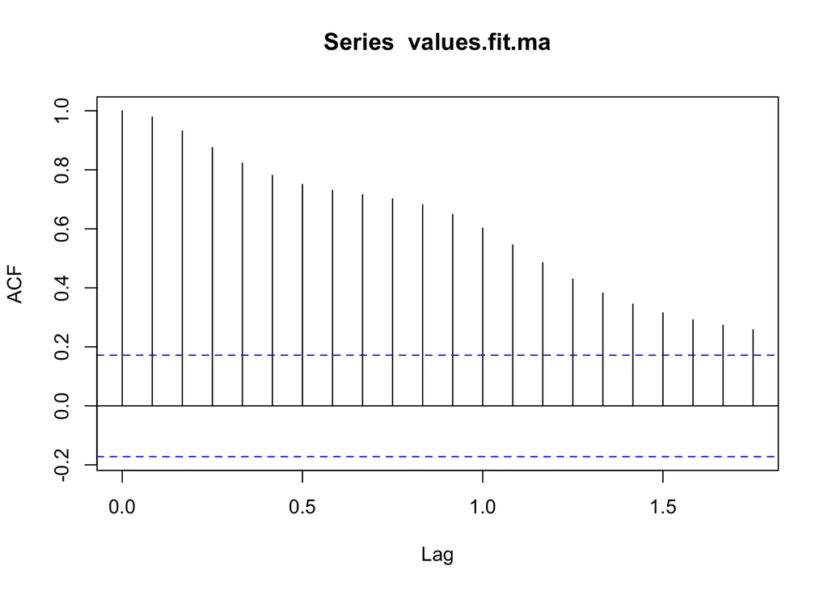

```r
values.fit.ma <- ts(na.omit(values.fit.ma), frequency=12, start=2008)
acf(values.fit.ma)
```

```r
adf.test(values.fit.ma)
```

```
##
##  Augmented Dickey-Fuller Test
##
## data:  values.fit.ma
## Dickey-Fuller = -1.6359, Lag order = 5, p-value = 0.7279
## alternative hypothesis: stationary
```

The data doesn´t appear to be stationary - it is apparent that mean and variance change over time. Looking at the ACF plot we can also reach the same conclusion, given there is no sharp drop in the values, but instead a smooth decay. So we need to transform our data to make it more stationary in order to use it for ARIMA models, for instance. This is further confirmed by running the ADF test: with a p-value = 0.7279 we can’t reject the null hypothesis of non-stationarity.

### Making the data stationary

Some of the possible mathematical transforms include: differencing, log (and Box-Cox), moving average, percent change, lag, or cumulative sum.

### Differencing

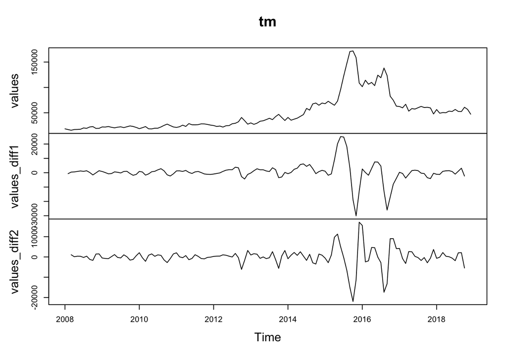

```r
values_diff1 = diff(values.fit.ma)
values_diff2 = diff(values_diff1)
tm <- cbind(values, values_diff1, values_diff2)
plot(tm)
```

A first difference seems to suffice here, but let’s check again this visual inspection by using an ACF plot and ADF test:

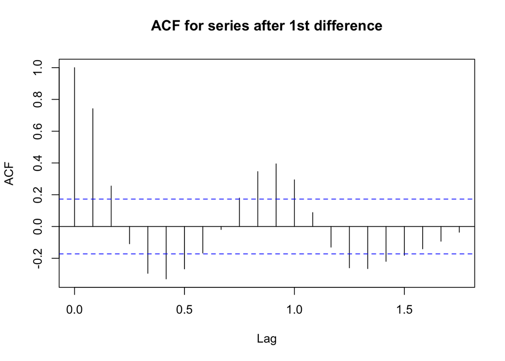

```r
acf(values_diff1, main="ACF for series after 1st difference")
```

```r
adf.test(values_diff1)
```

```
##
##  Augmented Dickey-Fuller Test
##
## data:  values_diff1
## Dickey-Fuller = -5.9055, Lag order = 5, p-value = 0.01
## alternative hypothesis: stationary
```

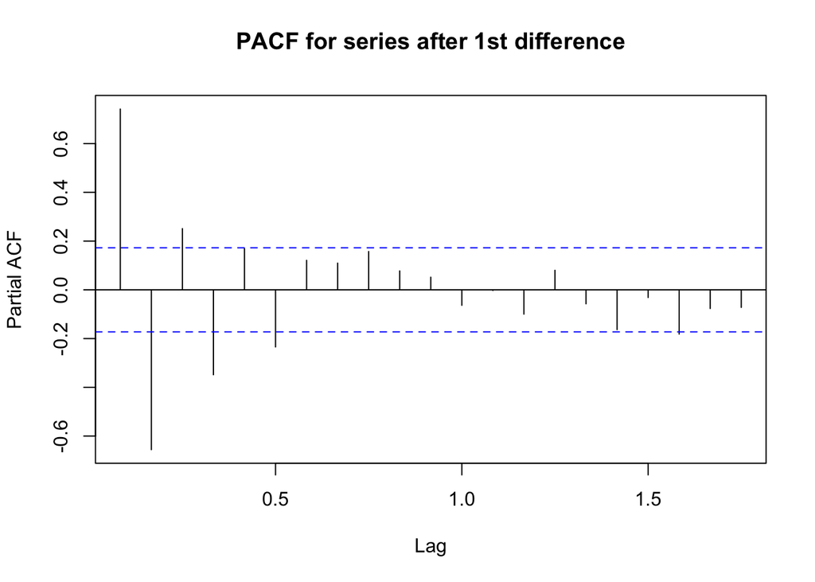

```r
pacf(values_diff1, main="PACF for series after 1st difference")
```

# 5. Model

## ARIMA(p, d, q) order

Taking the first difference seems to be sufficient to stationarize our data, which gives us one of the parameters, d. Reading the ACF and PACF models, there are a few values for the AR and MA parameters we can try to start with: 1, 2, 3, 5.

```r
arima(values.deseason, order=c(1, 1, 1))
```

```
##
## Call:
## arima(x = values.deseason, order = c(1, 1, 1))
##
## Coefficients:
##          ar1     ma1
##       0.6127  0.9603
## s.e.  0.0688  0.0194
##
## sigma^2 estimated as 6296682:  log likelihood = -1194.8,  aic = 2395.6
```

```r
arima(values.deseason, order=c(2, 1, 1))
```

```
##
## Call:
## arima(x = values.deseason, order = c(2, 1, 1))
##
## Coefficients:
##          ar1      ar2     ma1
##       0.8639  -0.3910  0.9421
## s.e.  0.0816   0.0814  0.0222
##
## sigma^2 estimated as 5336545:  log likelihood = -1184.43,  aic = 2376.85
```

```r
arima(values.deseason, order=c(1, 1, 2))
```

```
##
## Call:
## arima(x = values.deseason, order = c(1, 1, 2))
##
## Coefficients:
##          ar1     ma1     ma2
##       0.1278  1.8321  0.8590
## s.e.  0.1124  0.0869  0.0858
##
## sigma^2 estimated as 4965354:  log likelihood = -1180.85,  aic = 2369.7
```

```r
arima(values.deseason, order=c(1, 1, 3))
```

```
##
## Call:
## arima(x = values.deseason, order = c(1, 1, 3))
##
## Coefficients:
```

```
##           ar1     ma1     ma2     ma3
##       -0.7062  2.5639  2.1884  0.6163
## s.e.      NaN     NaN     NaN     NaN
##
## sigma^2 estimated as 5001194:  log likelihood = -1181.47,  aic = 2372.94
```

```r
arima(values.deseason, order=c(1, 1, 4))
```

```
##
## Call:
## arima(x = values.deseason, order = c(1, 1, 4))
##
## Coefficients:
```

```
##           ar1     ma1     ma2     ma3     ma4
##       -0.5969  2.5565  2.3944  1.0468  0.2203
## s.e.      NaN     NaN     NaN     NaN  0.0746
##
## sigma^2 estimated as 4747145:  log likelihood = -1178.17,  aic = 2368.33
```

```r
arima(values.deseason, order=c(4, 1, 1))
```

```
##
## Call:
## arima(x = values.deseason, order = c(4, 1, 1))
##
## Coefficients:
##          ar1      ar2     ar3      ar4     ma1
##       0.9085  -0.5590  0.2769  -0.2431  0.9235
## s.e.  0.0874   0.1201  0.1196   0.0867  0.0269
##
## sigma^2 estimated as 5009020:  log likelihood = -1180.57,  aic = 2373.14
```

Another method is to let auto.arima estimate parameters and see how they fit with our conclusions so far:

```r
auto.arima(values.deseason, seasonal = FALSE)
```

```
## Series: values.deseason
## ARIMA(4,1,4)
##
## Coefficients:
##          ar1      ar2      ar3     ar4     ma1      ma2     ma3     ma4
##       1.7325  -0.6718  -0.4853  0.3219  0.1571  -1.5244  0.0624  0.8228
## s.e.  0.1286   0.2460   0.2349  0.1042  0.1082   0.1054  0.0851  0.0796
##
## sigma^2 estimated as 4633000:  log likelihood=-1172.73
## AIC=2363.46   AICc=2364.97   BIC=2389.2
```

```r
auto.arima(values.fit.ma, seasonal = TRUE)
```

```
## Series: values.fit.ma
## ARIMA(5,1,0)(1,0,0)[12]
##
## Coefficients:
##          ar1      ar2     ar3      ar4     ar5    sar1
##       1.6199  -1.6228  1.2199  -0.7996  0.2691  0.1627
## s.e.  0.0855   0.1512  0.1786   0.1520  0.0862  0.0898
##
## sigma^2 estimated as 7622200:  log likelihood=-1203.79
## AIC=2421.57   AICc=2422.5   BIC=2441.59
```

Using the coefficients for ar1, ar2, etc we can write the equation for the fitted model.

# 6. Model evaluation

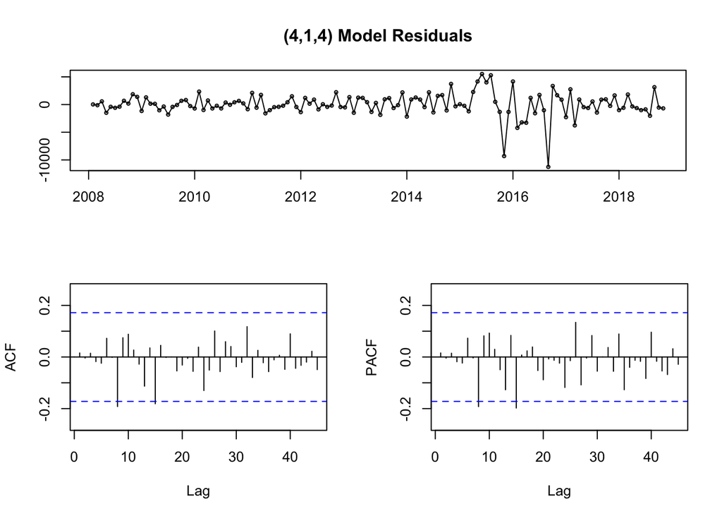

```r
values.model.arima <- arima(values.deseason, order=c(4,1,4))
tsdisplay(residuals(values.model.arima), lag.max=45, main='(4,1,4) Model Residuals')
```

Attempting a better fit after seeing the ACF and PACF charts

[figure not shown]

```r
values.model.arima2 <- arima(values.deseason, order=c(4,1,8))
tsdisplay(residuals(values.model.arima), lag.max=45, main='(4,1,8) Model Residuals')
```

```r
values.model.arima2
```

```
##
## Call:
## arima(x = values.deseason, order = c(4, 1, 8))
##
## Coefficients:
##          ar1      ar2     ar3      ar4     ma1      ma2     ma3      ma4
##       1.5669  -1.4385  1.1890  -0.6170  0.3314  -0.3356  0.0294  -0.7931
## s.e.  0.1907   0.2577  0.1882   0.1033  0.2177   0.1802  0.1489   0.1115
##          ma5     ma6     ma7     ma8
##       0.0387  0.7512  0.2147  0.1770
## s.e.  0.1541  0.1137  0.1762  0.1179
##
## sigma^2 estimated as 3916228:  log likelihood = -1168.27,  aic = 2362.55
```

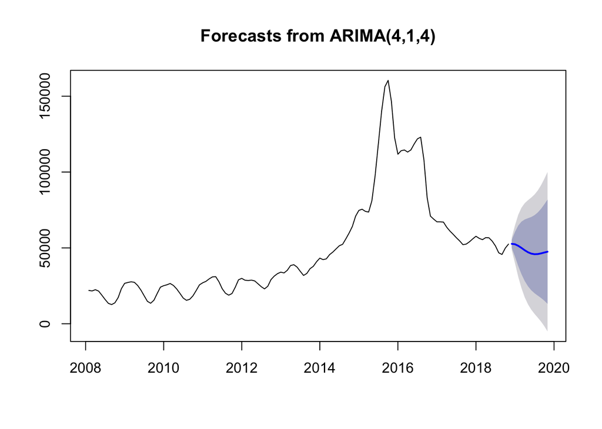

```r
forecast.values.arima <- forecast(values.model.arima, h=12)
plot(forecast.values.arima)
```